https://doi.org/10.1177/17474930211044870

International Journal of Stroke

2022, Vol. 17(5) 506 –516

© 2021 World Stroke Organization

Article reuse guidelines:

sagepub.com/journals-permissions

DOI: 10.1177/17474930211044870

journals.sagepub.com/home/wso

*Review*

Therapeutic hypothermia for

intracerebral hemorrhage: Systematic

review and meta-analysis of the

experimental and clinical literature

Turner S Baker<sup>1,2</sup>

, John Durbin<sup>1,2</sup>, Zachary Troiani<sup>2</sup>,

Luis Ascanio-Cortez<sup>2</sup>, Rebecca Baron<sup>1,2</sup>, Anthony Costa<sup>1,2</sup>,

Fred Rincon<sup>3</sup>, Frederick Colbourne<sup>4</sup>, Patrick Lyden<sup>5</sup>,

Stephan A Mayer<sup>6</sup>and Christopher P Kellner<sup>2</sup>

Abstract

Background: Intracerebral hemorrhage remains the deadliest form of stroke worldwide, inducing neuronal death

through a wide variety of pathways. Therapeutic hypothermia is a robust and well-studied neuroprotectant widely

used across a variety of specialties.

Aims: This review summarizes results from preclinical and clinical studies to highlight the overall effectiveness of

therapeutic hypothermia to improve long-term intracerebral hemorrhage outcomes while also elucidating optimal

protocol regimens to maximize therapeutic effect.

Summary of review: A systematic review was conducted across three databases to identify trials investigating the use

of therapeutic hypothermia to treat intracerebral hemorrhage. A random-effects meta-analysis was conducted on pre-

clinical studies, looking at neurobehavioral outcomes, blood brain barrier breakdown, cerebral edema, hematoma

volume, and tissue loss. Several mixed-methods meta-regression models were also performed to adjust for variance

p ¼ 0.02), cerebral edema (ES ¼ 1.32, p ¼ 0.0001), and blood brain barrier (ES ¼ 2.73, p � 0.00001). Therapeutic hypo-

thermia was not found to significantly affect hematoma expansion (ES ¼ �0.24, p ¼ 0.12) or tissue loss (ES ¼ 0.06,

p ¼ 0.68). Clinical study outcome reporting was heterogeneous; however, there was recurring evidence of therapeutic

hypothermia-induced edema reduction.

Conclusions: The combined preclinical evidence demonstrates that therapeutic hypothermia reduced multiple cell

death mechanisms initiated by intracerebral hemorrhage; yet, there is no definitive evidence in clinical studies. The

cooling strategies employed in both preclinical and clinical studies were highly diverse, and focused refinement of cooling

protocols should be developed in future preclinical studies. The current data for therapeutic hypothermia in intracer-

ebral hemorrhage remains questionable despite the highly promising indications in preclinical studies. Definitive rando-

mized controlled studies are still required to answer this therapeutic question.

Keywords

Cerebral hemorrhage, hypothermia, intracerebral hemorrhage, methodology, neuroprotection, rehabilitation, stroke,

treatment

Received: 5 May 2021; accepted: 16 August 2021

1Sinai BioDesign, Icahn School of Medicine at Mount Sinai, New York, NY,

USA

2Department of Neurosurgery, Icahn School of Medicine at Mount Sinai,

New York, NY, USA

3Department of Neurology, Thomas Jefferson University, Thomas

Jefferson University Hospital, Philadelphia, PA, USA

4Department of Psychology, University of Alberta, Edmonton, AB,

Canada

5Department of Physiology and Neuroscience, Keck School of Medicine,

Zilkha

Neurogenetic

Institute,

University

of

Southern

California,

California, USA

6Departments of Neurology and Neurosurgery, New York Medical

College, Westchester Medical Center Health Network, New York, NY,

USA

Corresponding author:

Turner S Baker, One Gustave L. Levy Place, Box 1136, New York, NY

10029, USA.

Email: turner.baker@icahn.mssm.edu

Introduction

Intracerebral hemorrhage (ICH) remains a destructive

disease the deadliest form of stroke with over 30% mor-

tality

at six

months

despite

years

of trials

and

research.<sup>1–3</sup>Immediate mechanical injury of the bleed

is compounded by secondary perihematomal edema

(PHE) and inﬂammation, which occurs immediately

following ICH.<sup>4–6</sup>Tissue loss can continue for several

months, allowing for the possibility of unique neuro-

protectant strategies.<sup>4–8</sup>Minimally invasive surgical

(MIS) evacuation of the hematoma remains a promis-

ing treatment under evaluation, but to date, no rando-

mized controlled trial has been able to demonstrate a

signiﬁcant beneﬁt.<sup>9,10</sup>

Therapeutic hypothermia (TH) has been shown to

reduce tissue injury in preclinical models of transient

focal ischemia, and for years was considered a robust

neuroprotectant following cardiac arrest.<sup>11–16</sup>While

some of the neuroprotective beneﬁt of TH has been

limited in the cardiac space, TH may still be an attract-

ive modality to interrupt the neuroinﬂammation after

ICH.<sup>17</sup>In practical terms, hypothermia poses an inter-

esting treatment paradigm, requiring dose-ﬁnding stu-

dies examining depth and duration of cooling similar to

that of drug trials. To better understand the current

evidence, we have conducted this systematic review of

preclinical and clinical studies with an emphasis on TH

cooling protocols, and conducted a meta-analysis on all

controlled preclinical studies.

Materials and methods

Search strategy and process

This review was conducted according to the PRISMA-

P guidelines for preparation of a systematic review

protocol.<sup>18,19</sup>A search was performed through three

databases:

MEDLINE,

SCOPUS,

and

EMBASE.

Search terms for each database can be found in supple-

mentary Table I. Literature results were imported to

Covidence

Systematic

Review

Software

(Veritas

Health Innovation, Melbourne, Australia) for review.

After the removal of duplicate studies, two authors (TB

and RB) screened studies based on title and abstract.

Relevant articles were exported for full-text review, and

two authors (TB and ZT/LA) utilized the inclusion and

exclusion criteria to include studies for ﬁnal qualitative

synthesis. At least two authors (TB and ZT/LA/JD)

independently extracted relevant protocol elements

and major ﬁndings.

Inclusion and exclusion criteria

Inclusion criteria for clinical studies were: (1) Adult

patients

diagnosed

with

spontaneous

hemorrhagic

stroke; (2) adult patients with both hemorrhagic and

ischemic stroke in which patients with spontaneous

hemorrhagic stroke could be extracted separately; (3)

patients treated with therapeutic hypothermia (lower

than 37<sup>�</sup>C); (4) therapeutic procedure reported.

Exclusion criteria for clinical studies were: (1) no

control group; (2) patients with ischemic stroke without

hemorrhagic conversion, hypoxic-ischemic encephalop-

athy, or subarachnoid hemorrhage; (3) studies focusing

on neonatal patients.

Inclusion criteria for preclinical studies were: (1)

animal ICH model; (2) treated ICH or ICH-related

symptoms with therapeutic hypothermia (lower than

37<sup>�</sup>C); (3) therapeutic procedure reported.

Exclusion criteria for preclinical studies were: (1) No

control group; (2) animal model with ischemic stroke or

hypoxic-ischemic encephalopathy; (3) animal models

have additional condition (e.g. induced or modeled

tumors) outside of ICH.

All reviews, meta-analyses, observational studies,

and commentaries were excluded.

Methodological quality assessment

Two reviewers (TB, JD) assessed the risk of bias and

methodological quality of all studies independently;

any disputes were mediated by a third reviewer, CK.

The scoring system for quality assessment of preclinical

studies was developed using the most recent STAIR

recommendations for preclinical trial study design<sup>20</sup>

as well as Cui et al. study design in their assessment

of deferoxamine in the treatment of ICH in animal

models.<sup>21</sup>

The

presence

of

the

following

criteria

earned a score of one point each, for a total of 10 pos-

sible points: (1) dose response; (2) therapeutic window;

(3) outcome measures; (4) acute outcome measure assess-

ment; (5) chronic outcome measure assessment; (6)

physiological monitoring; (7) randomization; (8) blinding;

(9) age of the animal; and (10) sex of the animal.

A modiﬁed version of the Physiotherapy Evidence

Database (PEDro) scale was used as the tool to assess

risk-of-bias in the clinical trials.<sup>22</sup>The PEDro scale

consists of 10 items; they are random allocation, con-

cealment of allocation, baseline equivalence, blind sub-

jects, blind therapists, blind assessors, intention-to-treat

analysis, adequate follow-up, between-group statistical

analysis, and measurement of data variability and point

estimates.<sup>23</sup>

Meta-analysis

Standardized mean diﬀerences were calculated for four

outcomes: blood–brain barrier (BBB) disruption, brain

water content, hematoma volume, and tissue loss

volume. Due to the reporting of multiple behavioral

measures, a two-level meta-analysis was performed for

this outcome, where standardized mean diﬀerences and

standard errors were calculated for each study and then

combined. Random eﬀects analysis was performed for

all outcomes, given the considerable heterogeneity of

measurement and reporting. Heterogeneity of each out-

come

was

tested

with

Cochrane’s

Q

statistic.

Publication bias was analyzed through funnel plot

asymmetry.<sup>24</sup>A mixed-methods meta-regression was

performed for each outcome, adjusting for random

between-study variance and ﬁxed within-study vari-

ance.<sup>25</sup>

A

second

mixed-methods

meta-regression

model adjusts for the above as well as additional ﬁxed

eﬀects: average study hypothermia application delay

and average study hypothermia treatment duration.

Meta-analysis was performed with RevMan v5.3 soft-

ware (The Nordic Cochrane Centre, The Cochrane

Collaboration, Copenhagen, Denmark). Meta-regres-

sion was performed with SAS<sup>�</sup>v9.4 software (SAS

Institute Inc., Cary, NC, USA).

Results

Characteristics of studies

The initial search yielded 1585 studies; 337 duplicates

were removed, and 1248 studies were screened by title

and abstract with 1140 deemed irrelevant. A total of

108 were screened by full-text analysis and assessed

for eligibility given the inclusion and exclusion criteria.

The ﬁnal emerging 26 studies consisted of 21 preclinical

studies and ﬁve clinical studies. Figure 1 outlines the

ﬂow of study selection. A large portion of studies were

excluded from the review, as they grouped subarach-

noid hemorrhage (SAH) with ICH, or did not include a

matched control group.

Therapeutic hypothermia in ICH preclinical

models

Preclinical experimental designs were heterogeneous

across studies, with many studies conducting multiple

experiments compared against a singular control group.

TH groups were frequently compared to both nor-

mothermia and sham-ICH procedures, where ICH

was never induced. Collagenase and autologous blood

injections were the most common ICH induction, and

various studies were identiﬁed for systemic and loca-

lized cooling strategies. A total of 16 studies used

Sprague-Dawley rats, three used Wistar rats, one used

C57/BL6 mice, and one used a porcine model. Ten

studies used systemic cooling through cold environ-

ments, evaporative heat loss, or both; one study used

systemic pharmacological cooling; six studies used local

cold room cooling and local implanted cooling coils.

Systemic cooling target temperatures ranged from 30

to

33<sup>�</sup>C,

while

local

cooling

target

temperatures

ranged from 11 to 33<sup>�</sup>C. Figure 2 outlines several key

relative frequencies of preclinical studies, while supple-

mentary Tables II and III contain quality scores and

descriptive

characteristics,

respectively,

for

each

included study. Mixed methods regression of eﬀect

size by study quality scores did not identify a signiﬁcant

correlation between study quality and improved scores

in

any

outcome:

behavioral

scores

(b ¼ 0.6187,

p ¼ 0.1115), BBB disruption (b ¼ �0.1307, p ¼ 0.7742),

brain water content (b ¼ �0.4188, p ¼ 0.2497), hema-

toma volume (b ¼ 0.03786, p ¼ 0.8831), or tissue loss

volume (b ¼ �0.1526, p ¼ 0.7765).

A majority of preclinical studies reported behavioral

outcomes, using a wide variety of methods. An overall

eﬀect

favoring

hypothermic

treatment

was

found

Figure 1. PRISMA study flow diagram. The flow of study

identification and selection. The original search within the

three databases resulted in 1585 records, 337 of which were

found to be duplicates. The remaining 1248 studies were

screened by title and abstract, finding 1140 studies to be

irrelevant, often due to no use of hypothermia as an inter-

vention. This process left 108 records to assess for eligibility

through full-text assessment. Full English texts were not

included in 27 screened studies, 14 had no ICH patients or

models within the study, 11 contained ICH data but did not

isolate it from other conditions, 10 studies were single-arm

and had no control group, 8 additional duplicates were

identified, 5 studies were reviews, 4 studies had no hypo-

thermia as an intervention, 2 only contained protocol

descriptions and one study focused on pediatric patients.

After screening, 26 studies were assessed in the review,

including 21 preclinical studies and 5 clinical studies.

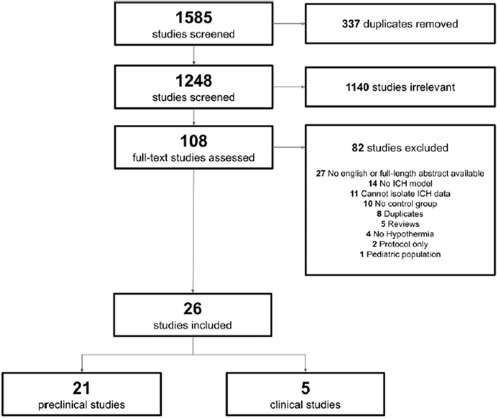

(Figure 3(a): ES ¼ 0.43, p ¼ 0.02), although heterogen-

eity

was

high

(Figure

3(a):

�<sup>2</sup>¼ 61.67,

df ¼ 14,

p � 0.00001). Visual inspection of the funnel plot (sup-

plementary Figure I(a)) yielded no apparent publica-

tion bias.

BBB disruption was reported in seven preclinical

studies, all measured by Evan’s Blue extravasation.

An overall eﬀect favoring hypothermic treatment was

found

(Figure

3(b):

ES ¼ 2.73,

p � 0.00001).

Heterogeneity

was

insigniﬁcant

in

this

analysis

(Figure 3(b): �<sup>2</sup>¼ 11.15, df ¼ 6, p ¼ 0.08). Visual inspec-

tion of the funnel plot (supplementary Figure I(b))

yielded no apparent publication bias.

Thirteen studies reported cerebral edema outcomes,

measured by brain water content. An overall eﬀect

favoring hypothermic treatment was found (Figure

3(c): ES ¼ 1.32, p ¼ 0.0001). Heterogeneity was signiﬁ-

cant in this analysis (Figure 3(c): �<sup>2</sup>¼ 77.59, df ¼ 12,

p � 0.00001). Visual inspection of the funnel plot

(supplementary Figure I(c)) yielded no apparent publi-

cation bias.

tion, and one study used both thrombin and collage-

nase injections. Autologous simulated hematomas were

excluded from this analysis, as there is no progressive

bleeding in this modality. Nine studies had progressive

hematoma modalities and reported changes in hema-

toma volume in a variety of ways, and are included in

this analysis. No signiﬁcant overall eﬀect of cooling was

found, although the average eﬀect favored normother-

mic treatment (Figure 4(a): ES ¼ �0.24, p ¼ 0.12).

Heterogeneity

was

insigniﬁcant

in

this

analysis

(Figure 4(a), �<sup>2</sup>¼ 10.15, df ¼ 8, p ¼ 0.25). Visual inspec-

tion of the funnel plot (supplementary Figure I(d))

yielded no apparent publication bias.

Eight studies reported tissue loss outcomes, measured

by lesion volume or total tissue lost, and are included in

this analysis. No overall eﬀect was found (Figure 4(b):

Visual inspection of the funnel plot (supplementary

Figure I(e)) yielded no apparent publication bias.

Mixed methods meta-regression of each outcome

adjusted for between study and within-study variance

did not appreciably change eﬀect size or signiﬁcance

(supplementary Table IV). Additional adjustment for

hypothermia treatment delay, treatment duration, and

local vs. systemic cooling showed no signiﬁcant associ-

ations in any of the outcomes (supplementary Table V).

Therapeutic hypothermia in clinical trials

Clinical studies consisted of two randomized controlled

trials (RCTs), a nonrandomized prospective study, and

two historically controlled trials. Studies were con-

ducted in China, Malaysia, and Germany. Clinical stu-

dies averaged a PEDro score of 4.4, and all but one of

the studies achieved a score of 5.<sup>26–29</sup>No study met the

predetermined deﬁnition of ‘‘good quality’’ for a con-

trolled trial (supplementary Figure II). A majority of

studies were non-randomized or used historical cohorts

as the control, thereby not allowing for blinding or

allocation concealment.<sup>26,27</sup>Details of the individual

study designs, TH protocols, and maintenance are out-

lined in Table 1. Two RCTs were identiﬁed, but had

short follow-up periods, and did not describe blinding

or allocation concealment protocols.<sup>28,29</sup>Abdullah and

Husin<sup>30</sup>performed a non-randomized, unblinded pro-

spective study, receiving the lowest score of 2. A meta-

analysis was not performed due to the high degree of

heterogeneity in outcome reporting between the studies

(supplementary Table VI).

Figure 2. Relative frequencies of preclinical experimental

designs. (a) ICH was primarily induced via direct collagenase

or autologous blood infusion, with few studies opting for

thrombin or other methods. Volume of injections varied

widely across studies. (b) Preclinical studies were split nearly-

evenly between systemic cooling and localized cooling tech-

niques. (c) Hypothermia induction methods varied greatly

across preclinical studies.

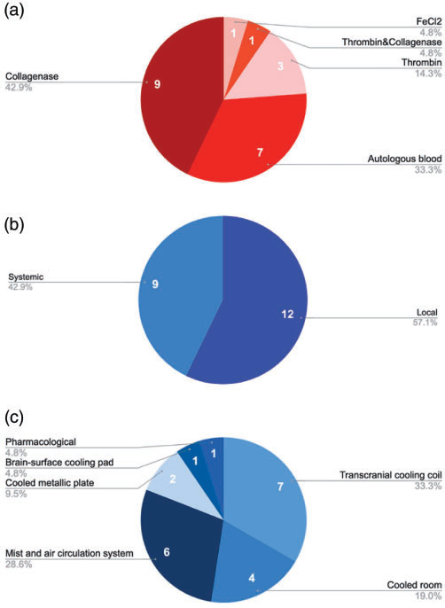

Staykov et al.<sup>26</sup>and Volbers et al.<sup>27</sup>both assessed the

use of mild systemic hypothermia as compared to his-

torically matched controls. Staykov et al.<sup>26</sup>found a sig-

niﬁcant reduction in PHE in response to immediate

cooling

and

no

signiﬁcant

change

in

hematoma

growth. Pneumonia and shivering were signiﬁcantly ele-

vated in the TH group, and there was no signiﬁcant

beneﬁt in functional outcomes. Volbers et al.<sup>27</sup>varied

the delay in cooling following the hemorrhage, seeing a

signiﬁcant reduction in edema following cooling under

Figure 3. Forest plots of preclinical studies showing significant improvement in ICH mechanisms and outcomes following

therapeutic hypothermia. (a) Fifteen studies reported behavioral outcomes. Meta analysis of standardized mean differences

showed significant improvement in animals that were treated with TH. (b) Seven studies reported blood-brain barrier disruption

outcomes measured by Evans Blue dye extravasation. Combined analysis demonstrated significant reduction in BBB disruption in

animals treated with TH. (c) Thirteen studies reported cerebral edema measured by brain water content, with outcomes con-

verted to standardized mean differences. A significant reduction in edema formation was seen in animals that underwent TH.

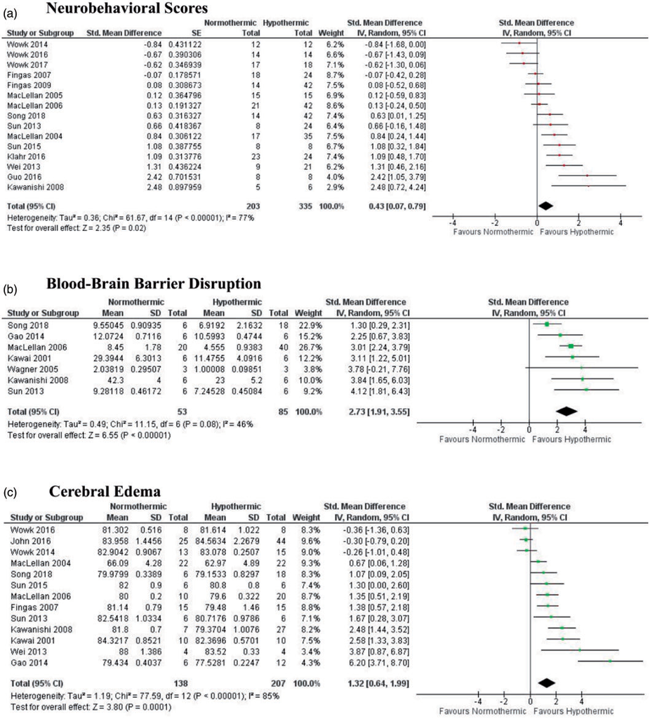

two days, with no signiﬁcant eﬀect on edema when cool-

ing was induced four days following the bleed. Duration

of TH was also varied, with no signiﬁcant diﬀerence

seen in terms of extended cooling duration (Table 2).

Su et al.<sup>28</sup>was the only study found to induce loca-

lized cooling, inducing TH via a head wrap. Minimal

clinical outcomes were reported, but the cooled group

was found to have a signiﬁcant improvement in

Figure 4. Forest plots of preclinical studies showing no significant difference in ICH mechanisms and outcomes between cooled

and control animals. (a) Nine studies reported hematoma volumes which were converted to standardized mean differences. There

was no significant effect involving hypothermia treatment and hematoma volume. (b) Eight studies reported tissue loss (measured

by lesion size) outcomes which were converted to standardized mean differences. There was no significant effect involving

hypothermia treatment and tissue loss.

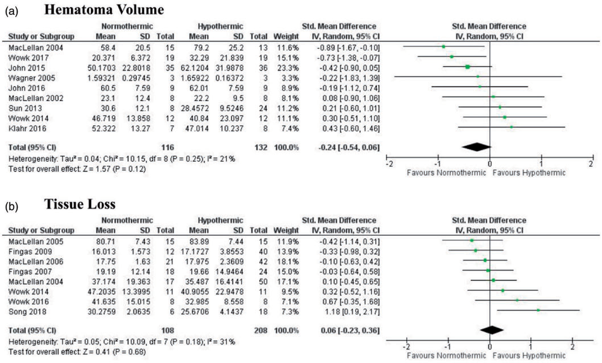

Table 1. Therapeutic hypothermia protocols of included clinical studies.

Hypothermia

type

Hypothermia

method

Interval from

onset to cooling

Target

temperature

Duration of

hypothermia

Rewarming

rate

Abdullah et al.<sup>30</sup>

Systemic

Cooling central

venous catheter

Not reported

34<sup>�</sup>C

24 h

1<sup>�</sup>C per h

Staykov et al.<sup>26</sup>

Systemic

Cooling central

venous catheter

<24 h

35<sup>�</sup>C

8–10 days

0.5 LC per 24

Su et al.<sup>28</sup>

Local

Surface head

cooling

3.67 h

33–35<sup>�</sup>C

72 h

<1<sup>�</sup>C per 4–6 h

Volbers et al.<sup>27</sup>

Systemic

Cooling central

venous catheter

1–2 days (n ¼ 30)

4–5 days (n ¼ 3)

35<sup>�</sup>C

3–8 days (n ¼ 21)

0.5<sup>�</sup>C per 24 h

Zhao et al.<sup>29</sup>

Systemic

Surface-cooling

not reported

32.5–34.5<sup>�</sup>C

3–7 days

0.5<sup>�</sup>C per 12 h

Table 2. Key outcomes and characteristics of included clinical studies.

References

Control

N

Age Years

(SD)

Gender

%Female

Baseline

hematoma

volume (mL)

Follow-up

period

Peak PHE

volume,

mL (SD)

Mortality

Dead (%)

Key results

Abdullah

et al.30

Standard

medical

treatment

I: 6

C: 18

I: 49.8

C: 60.7

I: 66.7

C: 66.7

Not reported

One year

Not reported

Not reported

Hematoma volume: Not reported.

PHE: Not reported.

Functional score (mRS): Follow-up

mRS was significantly lower in

the intervention group, and

represented greater decrease

from baseline.

Other findings: Not reported.

Staykov

et al.26

Standard

medical

treatment

(historical

matched

control)

I: 25

C: 25

I: 63 (9.3)

C: 67 (7.5)

I: 44%

C: 40%

I: 54,4 (25)

C: 57.4 (31.1)

One year

Day 14

C: 53.4 (7.9)

3-month

I: 2 (8%)

C: 7 (28%)

1-year

I: 4 (16%)

C: 11 (44%)

Hematoma Volume: There were

no significant difference in

hematoma volume overthe 14

days between groups.

PHE: Edema in the TH group was

stable compared to the control,

and significantly reduced on

days 3–14.

Functional score (mRS): There was

no significant difference

between groups.

Other findings: Pneumonia (96%)

and shivering occurred at higher

rates in the TH group com-

pared to control. Deep vein

thrombosis, pulmonary embol-

ism, bradycardia, and thrombo-

cytopenia were also higher in

the TH group. Proportion with

myocardial infarction was lower

in the TH group

Su et al.28

Standard

medical

treatment

I: 19

C: 17

I: 60.21 (12.85)

C: 58.59 (15.11)

I: 42%

C: 53%

Not reported

21 Days

Not reported

Not reported

Hematoma volume: Not reported.

PHE: Not reported.

Functional score (NIHSS/GCS):

The TH group has a greater

improvement in NIHSS and

GCS compared to the control.

Other findings: Regional cerebral

blood flow was significantly

elevated in the TH group.

(continued)

Table 2. Continued.

References

Control

N

Age Years

(SD)

Gender

%Female

Baseline

hematoma

volume (mL)

Follow-up

period

Peak PHE

volume,

mL (SD)

Mortality

Dead (%)

Key results

Volbers

et al.27

Standard

medical

treatment

(historical

matched

control)

I: 33

C: 37

I: 63 (11)

C: 64.7 (10)

I: 48%

C: 41.5%

I: 45.8 (29.2)

C: 45.3 (24.3)

90 Days

I: 70.784 (21.567)

C: 78.72 (33.12)

90-day

I: 4 (15.4%)

C: 7 (13.8%)

Hematoma volume: Secondary

hematoma expansion was sig-

nificantly elevated in the TH

group compared to control.

PHE: Relative edema was substan-

tially lower in patients cooled

within one to two days. No

significant difference in edema

was seen between control and

TH initiated 4þ days after

onset. There were no significant

differences between short or

long TH therapy when induced

within 1–2 days.

Functional score (mRS): Median

mRS did not differ between

groups.

Other findings: There were no

difference in complications

between groups.

Zhao et al.29

Standard

medical

treatment

matched

control)

I: 103

C: 103

I: 52.87 (14.40)

C: 51.53 (15.39)

Not reported

I: 39.02 (10.74)

C: 38.19 (9.32)

Seven days

Not reported

Not reported

Hematoma Volume: Not reported.

PHE: Not reported.

Functional score (NIHSS): The TH

group has significant improve-

ments in NIHSS at

the three- and seven-day follow-up

periods compared to the con-

trol.

Other findings: TNF-alpha and NF-

kB were significantly reduced in

the TH group.

There were no difference in

complications.

Total

I: 186 C: 200

Note: Key characteristics of the clinical studies identified are summarized. Hematoma volume, follow-up periods, PHE volume, mortality, and key results were reported.

TH: therapeutic hypothermia; PHE: perihematomal edema mRS: modified Rankin Score; NIHSS: National Institute of Health Stroke Scale; rCBF: regional cerebral blood flow; TNF-alpha: tumor necrosis

factor alpha; NF-kB: nuclear factor-kB.

functional outcomes compared to control. Regional

cerebral blood ﬂow measured with SPECT imaging

was also reported to have increased (Table 2).

Zhao et al.<sup>29</sup>was the only identiﬁed study that

assessed the combination therapy of ICH evacuation

and TH, and was the only study that induced systemic

hypothermia via surface cooling. National Institute of

Health Stroke Scale (NIHSS) scores were found to be

signiﬁcantly reduced at both the follow up periods;

however, follow-up was limited to only seven days

and few other clinical characteristics were described.

The

study

was

randomized

and

had

the

largest

sample size of any trial identiﬁed, with 206 subjects.

The primary aim of the study was to identify the

eﬀect of TH on inﬂammatory markers, demonstrating

a signiﬁcant reduction in tumor necrosis factor alpha

(TNF-alpha) and nuclear factor Kappa-light-chain-

enhancer of activated beta cells (NF-kb) in the cooled

group compared to the control (Table 2).

Discussion

A systematic review of the literature focusing on TH to

treat ICH was conducted, identifying 21 preclinical and

ﬁve clinical studies comparing TH to control. Current

preclinical evidence demonstrates signiﬁcant improve-

ments in behavioral, BBB disruption, and edema out-

comes following TH, but conclusive clinical RCTs in

humans have not been conducted.

The meta-analysis of the preclinical studies found a

clear beneﬁt to ICH-related injury in response to TH,

improving neurologic outcome, reducing perihema-

toma edema, and reducing BBB breakdown. This ana-

lysis expands on the prior work of Melmed and

Lyden<sup>31</sup>by adding additional studies that have been

performed in the interim and including clinical studies.

In our analysis, we broke lesion size into its two com-

monly reported components: hematoma expansion and

ICH-related tissue loss. Our ﬁndings found tissue loss

to not be aﬀected by TH, and while hematoma volume

was also found to be non-signiﬁcant, there was a clear

trend towards expansion in association with TH.

Hematoma expansion due to TH has been hypothe-

sized to be a result of increased blood pressure soon

after hemorrhage,<sup>32</sup>inhibition of coagulopathy,<sup>32</sup>or a

propensity towards delayed rebleeding.<sup>33</sup>The eﬀect is

likely to be multifaceted and careful preclinical experi-

mentation will be required to determine if beneﬁcial

eﬀects of TH on cerebral edema and BBB disruption

can be promoted while minimizing potentially harmful

eﬀects of TH on hematoma expansion. Without con-

sistent signiﬁcant ﬁndings contraindicating TH for ICH

because of hematoma expansion, the relationship is dif-

ﬁcult to identify. This is clinically important, as the

potential for TH to negatively aﬀect coagulation and

hematoma growth is a primary concern of future clin-

ical RCTs. While some preclinical studies suggested a

trend of increased bleeding following early cooling in

collagenase ICH models, a meta-regression analysis

demonstrated that cooling protocol elements did not

signiﬁcantly impact the overall positive eﬀect of cool-

ing. While this may suggest that ICH outcomes are

dose independent, there was extensive variation in

design across the preclinical studies, particularly in

the dosing of TH, which may have limited the ability

for the meta-regression to detect trends.

While conclusive, the preclinical evidence could be

improved with additional testing. All BBB analysis was

performed using Evan’s Blue extravasation, which has

been criticized previously.<sup>8,34</sup>All but one preclinical

study was performed on young or adult rats or mice,

with one study using adult pigs. This substantially dif-

fers from a majority of ICH patients, who tend to be

elderly. It is possible that the use of younger animal

models overestimates the true eﬃcacy of TH in a real-

world setting. Additional preclinical testing using older

or hypertensive animal models would bolster the cur-

rent level of preclinical evidence. These studies may also

shed greater light on the potential risks of cooling-

induced rebleeding, as hypertensive rats are known to

be at greater risk of bleeding. The major limitation of

this meta-analysis was the combining of interventions

to conduct the analysis; many of the preclinical studies

used the same control group to test intervention groups

with varied sample sizes, which would artiﬁcially

increase sample size should they be assessed independ-

ently. While this solidiﬁes the signiﬁcant ﬁndings in

edema, BBB, and neurobehavioral scores, it may also

explain why hematoma volume was found to be insig-

niﬁcant. Future preclinical work should begin to focus

on a central ICH-induction strategy and cooling proto-

col in order to clearly distinguish optimal procedures.

The lack of deﬁnitive outcomes in clinical testing

may also be due to the incongruencies between preclin-

ical and clinical cooling protocols. A large portion of

preclinical studies used focal cooling methods to induce

TH. The negative side-eﬀects of systemic hypothermia

are well documented, and focal hypothermia may

achieve the beneﬁts of TH while minimizing the pitfalls

of systemic cooling. Su et al.<sup>28</sup>was the only study that

performed a controlled clinical study assessing the use

of focal cooling, ﬁnding a signiﬁcant improvement in

functional outcome within the cooled group compared

to controls. Several uncontrolled clinical studies have

been conducted in recent years utilizing transcranial

and intranasal cooling techniques, and the development

of speciﬁc tools and techniques to induce focal cooling

in ICH would be beneﬁcial in combination with a larger

controlled study.<sup>35,36</sup>The time between bleed and TH

initiation was shorter in all preclinical studies compared

to identiﬁed human trials, likely due to the inherent

obstacles in rapidly cooling ICH patients. While this

may explain the increased beneﬁt to edema reduction

in preclinical results, the potential for TH to negatively

impact hematoma growth is highest immediately fol-

lowing the bleed, thereby increasing the risk of rapid

cooling. Duration of cooling was found to be signiﬁ-

cantly shorter in preclinical studies compared to human

trials. All clinical trials except Abdullah et al.<sup>30</sup>report a

cooling duration of three or more days, while only

seven preclinical trials have hypothermia durations

more than 24 h. Given the immediate initiation and

growth of the edema, short-term cooling may do

enough to inhibit the evolution of the inﬂammatory

cascade caused by the hemorrhage, as suggested in pre-

clinical results, but PHE is known to progress over sev-

eral days and increased cooling durations may further

improve outcomes if the side eﬀects of long-term TH

can be mitigated.

Distinctly lacking from both preclinical and clinical

data is the combination of TH with minimally invasive

evacuation of the hematoma prior to cooling. Zhao

et al.<sup>29</sup>is the only study identiﬁed that tested this com-

bination therapy, ﬁnding improved neurological scores

and reduced inﬂammatory markers. China has already

adopted surgical evacuation of the hematoma following

ICH as standard of care, explaining the increased

sample size within Zhao et al. A separate meta-analysis

was identiﬁed that reported an emphatic beneﬁt of TH

on ICH when combined with evacuation, but all studies

were published in Chinese, and none of the cited articles

could be identiﬁed or conﬁrmed.<sup>37</sup>

The substantial preclinical data indicates that TH

may still be a promising avenue for treating ICH; how-

ever, the lack of substantial clinical evidence and recent

ﬁndings in cardiac arrest<sup>38</sup>dampens optimism. In order

for TH to prove eﬀective in improving ICH outcomes,

additional optimization of cooling protocols is needed

to induce optimal eﬀect while minimizing potential

negative eﬀects like worsened bleeding, inhibition of

beneﬁcial inﬂammation, or interference with brain plas-

ticity. A wide array of preclinical experiments has been

conducted, and it is important for controlled human

studies to attempt to reproduce the success of preclin-

ical ﬁndings despite the varied nature of preclinical

cooling procedures. Future clinical trials must extrapo-

late from the cooling protocols identiﬁed in animal stu-

dies to optimize the key mechanisms seen while

accounting for diﬀerences in the triage and clinical set-

ting. It is important to note that the preclinical work

has been varied in procedure, and no clearly successful

protocol has been identiﬁed. Nonetheless, ﬁnding ways

to cool the area of inﬂammation locally has clear bene-

ﬁts to the weakened ICH patient population, who

struggle with the eﬀects of shivering, pneumonia, and

other systemic cooling eﬀects. The use of TH may fur-

ther beneﬁt from a combination treatment alongside

clot evacuation. This may prove a symbiotic combin-

ation, with evacuation focusing on minimizing the mass

eﬀect and iron toxicity of the bleed, and TH minimizing

the secondary inﬂammatory response. It is important

for additional RCTs to be conducted to identify opti-

mal cooling protocols for this patient population and

informed by the expansive work already conducted in

preclinical experiments.

Acknowledgments

Apart from the authors, no other persons have made substan-

tial contributions to this article.

Declaration of conflicting interests

The author(s) declared no potential conﬂicts of interest with

respect to the research, authorship, and/or publication of this

article.

Funding

The author(s) received no ﬁnancial support for the research,

authorship, and/or publication of this article.

ORCID iD

Turner S Baker

https://orcid.org/0000-0002-3440-9563

References

1. Guo T, Ren P, Li X, et al. Neural injuries induced by

hydrostatic pressure associated with mass effect after intra-

cerebral hemorrhage. Sci Rep 2018; 8: 9195.

2. Wilkinson DA, Pandey AS, Thompson BG, et al. Injury

mechanisms

in

acute

intracerebral

hemorrhage.

Neuropharmacology 2018; 134: 240–248.

3. van Asch CJJ, Luitse MJA, Rinkel GJE, et al. Incidence,

case fatality, and functional outcome of intracerebral

haemorrhage over time, according to age, sex, and ethnic

origin: a systematic review and meta-analysis. Lancet

Neurol 2010; 9: 167–176.

4. Zazulia AR, Diringer MN, Derdeyn CP, et al. Progression

of mass effect after intracerebral hemorrhage. Stroke 1999;

30: 1167–1173.

5. Gebel JM Jr, Jauch EC, Brott TG, et al. Natural history of

perihematomal edema in patients with hyperacute spontan-

eous intracerebral hemorrhage. Stroke 2002; 33: 2631–2635.

6. Venkatasubramanian C, Mlynash M, Finley-Caulfield A,

et al. Natural history of perihematomal edema after intra-

cerebral hemorrhage measured by serial magnetic reson-

ance imaging. Stroke 2011; 42: 73–80.

7. Nguyen AP, Huynh HD, Sjovold SB, et al. Progressive

brain damage and alterations in dendritic arborization

after collagenase-induced intracerebral hemorrhage in

rats. Curr Neurovasc Res 2008; 5: 171–177.

8. MacLellan CL, Silasi G, Poon CC, et al. Intracerebral hem-

orrhage models in rat: comparing collagenase to blood infu-

sion. J Cereb Blood Flow Metab 2008; 28: 516–525.

9. Hanley DF, Thompson RE, Rosenblum M, et al. Efficacy

and safety of minimally invasive surgery with thrombolysis

in intracerebral haemorrhage evacuation (MISTIE III): a

randomised, controlled, open-label, blinded endpoint

phase 3 trial. Lancet 2019; 393: 1021–1032.

10. Hanley DF, Thompson RE, Muschelli J, et al. Safety and

efficacy of minimally invasive surgery plus alteplase in

intracerebral haemorrhage evacuation (MISTIE): a ran-

domised, controlled, open-label, phase 2 trial. Lancet

Neurol 2016; 15: 1228–1237.

11. Zhao H and Steinberg G. Limited therapeutic time win-

dows of mild-to-moderate hypothermia in a focal ische-

mia model in rat. Stroke Res Treat 2011; 2011: 131834.

12. Dumitrascu OM, Lamb J and Lyden PD. Still cooling

after all these years: meta-analysis of pre-clinical trials

of therapeutic hypothermia for acute ischemic stroke.

J Cereb Blood Flow Metab 2016; 36: 1157–1164.

13. van der Worp HB, Macleod MR, Kollmar R, et al.

Therapeutic hypothermia for acute ischemic stroke:

ready to start large randomized trials? J Cereb Blood

Flow Metab 2010; 30: 1079–1093.

14. Polderman KH. Induced hypothermia and fever control

for prevention and treatment of neurological injuries.

Lancet 2008; 371: 1955–1969.

15. Kollmar R and Schwab S. Hypothermia in focal ische-

mia:

implications

of

experiments

and

experience.

J Neurotrauma 2009; 26: 377–386.

16. Colbourne F, Corbett D, Zhao Z, Yang J and Buchan

AM. Prolonged but delayed postischemic hypothermia: a

long-term outcome study in the rat middle cerebral artery

occlusion model. J Cereb Blood Flow Metab 2000; 20:

1702–1708.

17. Mracsko E and Veltkamp R. Neuroinflammation after

intracerebral hemorrhage. Front Cell Neurosci 2014; 8: 388.

18. Moher D, Shamseer L, Clarke M, et al. Preferred report-

ing items for systematic review and meta-analysis proto-

cols (PRISMA-P) 2015 statement. Syst Rev 2015; 4: 1.

19. Sacks HS, Berrier J, Reitman D, Ancona-Berk VA and

Chalmers TC. Meta-analyses of randomized controlled

trials. N Engl J Med 1987; 316: 450–455.

20. Fisher M, Feuerstein G, Howells DW, et al. Update of

the stroke therapy academic industry roundtable preclin-

ical recommendations. Stroke 2009; 40: 2244–2250.

21. Cui H-J, He H-Y, Yang A-L, et al. Efficacy of deferox-

amine in animal models of intracerebral hemorrhage: a

systematic review and stratified meta-analysis. PLoS One

2015; 10: e0127256.

22. Bhogal SK, Teasell RW, Foley NC and Speechley MR.

The PEDro scale provides a more comprehensive meas-

ure of methodological quality than the Jadad Scale in

stroke rehabilitation literature. J Clin Epidemiol 2005;

58: 668–673.

23. Gonzalez

GZ,

Moseley

AM,

Maher

CG,

et

al.

Methodologic quality and statistical reporting of physical

therapy randomized controlled trials relevant to muscu-

loskeletal conditions. Arch Phys Med Rehabil 2018; 99:

129–136.

24. Higgins J, Green S (eds). Cochrane handbook for systema-

tic reviews of interventions. Chichester, England: John

Wiley & Sons, 2007.

25. Sheu CF and Suzuki S. Meta-analysis using linear mixed

models. Behav Res Methods Instrum Comput 2001; 33:

102–107.

26. Staykov D, Wagner I, Volbers B, et al. Mild prolonged

hypothermia

for

large

intracerebral

hemorrhage.

Neurocritical Care 2013; 18: 178–183.

27. Volbers B, Herrmann S, Willfarth W, et al. Impact of

hypothermia initiation and duration on perihemorrhagic

edema evolution after intracerebral hemorrhage. Stroke

2016; 47: 2249–2255.

28. Su X, Zheng K, Ma Q, et al. Effect of local mild hypo-

thermia on regional cerebral blood flow in patients with

acute intracerebral hemorrhage assessed by 99mTc-ECD

SPECT imaging. J X-Ray Sci Technol 2015; 23: 101–109.

29. Zhao J, Mao Q, Qian Z, Zhu J, Qu Z, Wang C. Effect of

mild hypothermia on expression of inflammatory factors

in surrounding tissue after minimally invasive hematoma

evacuation in the treatment of hypertensive intracerebral

hemorrhage. Exp Ther Med. 2018 Jun; 15(6): 4906–4910.

doi: 10.3892/etm.2018.6014. Epub 2018 Mar 30. PMID:

29805513; PMCID: PMC5952095.

30. Abdullah JM and Husin A. Intravascular hypothermia

for acute hemorrhagic stroke: a pilot study. Acta

Neurochir Suppl 2011; 111: 421–424.

31. Melmed KR and Lyden PD. Meta-analysis of pre-clinical

trials of therapeutic hypothermia for intracerebral hem-

orrhage.

Ther

Hypothermia

Temp

Manag

2017;

7:

141–146.

32. MacLellan CL, Girgis J and Colbourne F. Delayed onset

of prolonged hypothermia improves outcome after intra-

cerebral hemorrhage in rats. J Cereb Blood Flow Metab

2004; 24: 432–440.

33. Wowk S, Fagan KJ, Ma Y, Nichol H and Colbourne F.

Examining potential side effects of therapeutic hypother-

mia in experimental intracerebral hemorrhage. J Cereb

Blood Flow Metab 2017; 37: 2975–2986.

34. Nadeau CA, Dietrich K, Wilkinson CM, et al. Prolonged

blood-brain barrier injury occurs after experimental intra-

cerebral hemorrhage and is not acutely associated with

additional bleeding. Transl Stroke Res 2019; 10: 287–297.

35. Abou-Chebl A, Sung G, Barbut D and Torbey M. Local

brain temperature reduction through intranasal cooling

with the RhinoChill device: preliminary safety data in

brain-injured patients. Stroke 2011; 42: 2164–2169.

36. Poli S, Purrucker J, Priglinger M, et al. Safety evaluation of

nasopharyngeal cooling (RhinoChill<sup>�</sup>) in stroke patients:

an observational study. Neurocrit Care 2014; 20: 98–105.

37. Han Y, Sheng K, Su M, Yang N and Wan D. Local mild

hypothermia therapy as an augmentation strategy for

minimally invasive surgery of hypertensive intracerebral

hemorrhage: a meta-analysis of randomized clinical trials.

Neuropsychiatric Dis Treat 2016; 13: 41–49.

38. Dankiewicz J, Cronberg T, Lilja G, et al. Hypothermia

versus normothermia after out-of-hospital cardiac arrest.

N Engl J Med 2021; 384: 2283–2294.